# Quitobaquito

Janelle Christensen, Mike Tercek

8/20/2020

# Water balance graphs for different climate futures

We used information from a nearby location, Tumacacori which is south of Tuscon, approximately 200 miles from Quitobaquito to look at the range of possible climate futures in the area. After evaluating this information, we chose two climate futures that are distinctly different - inmcm4 RCP 4.5 to display projections for a future that is hotter and drier, and HadGEM2-CC365RCP 8.5 to display projections for a future that is *much* hotter and *much* drier.

Data is based on water balance data projections from Mike Tercek.

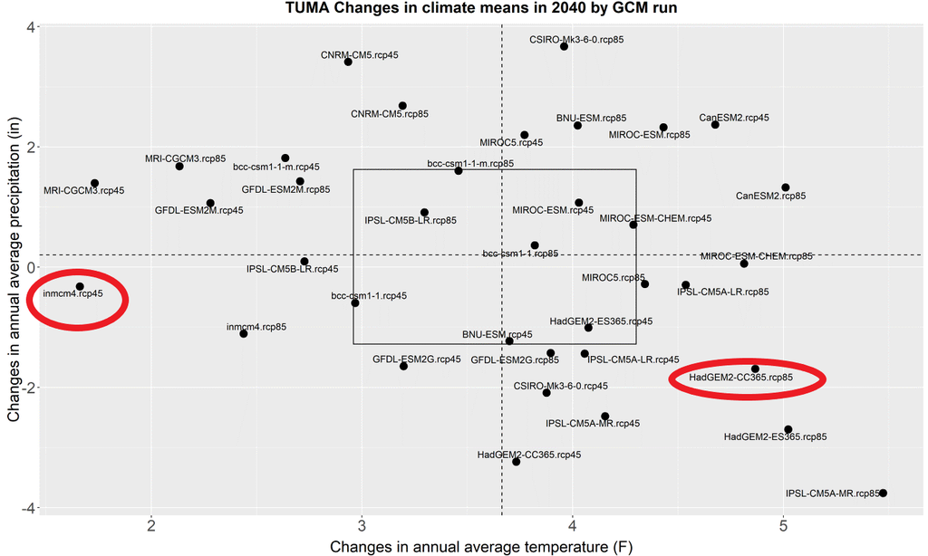

These charts represent seasonality of and annual average of time series. The graphs that show this time series by day of year represent changes in timing and magnitude throughout the year. The graphs of annual averages until 2100 represent changes over time, and display what the climate may look like by the end of this century.

## Rain

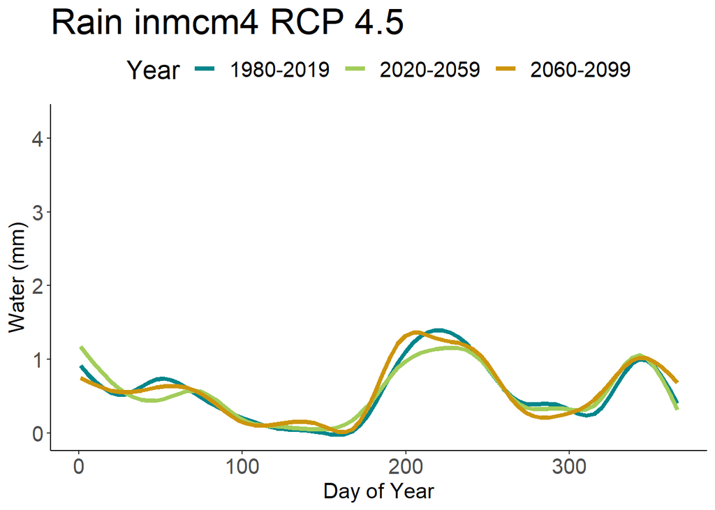

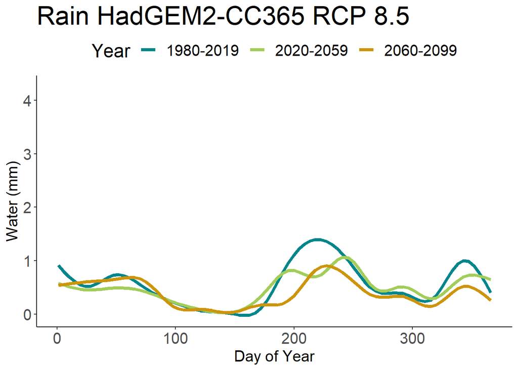

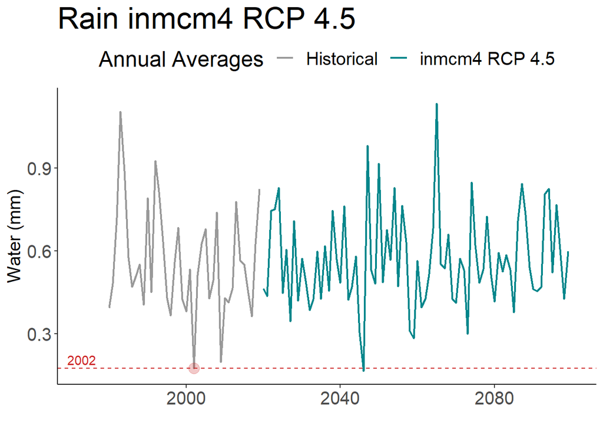

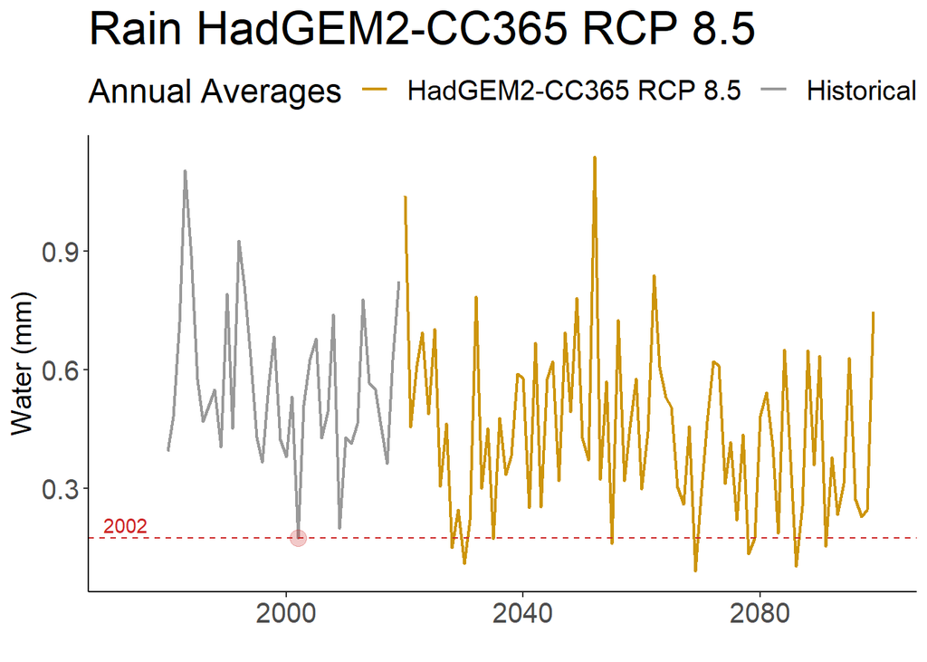

## Actual Evapotranspitation

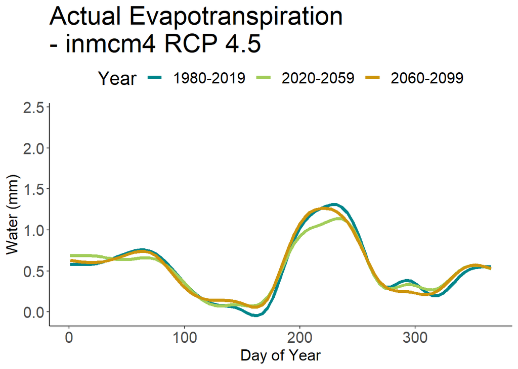

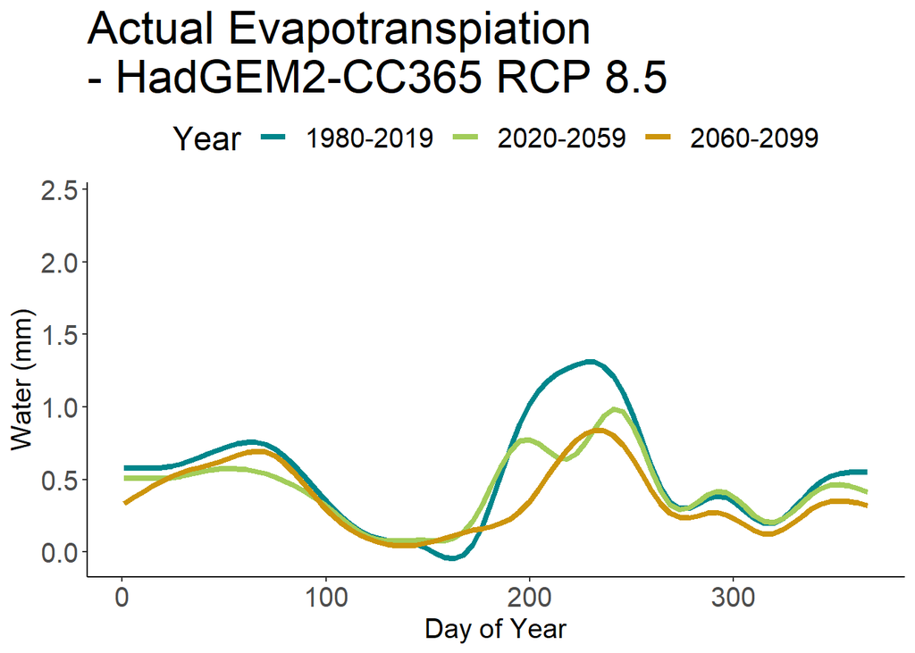

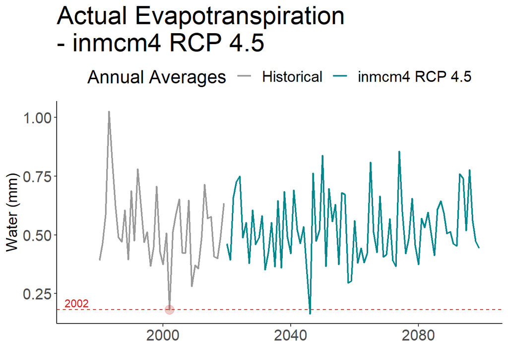

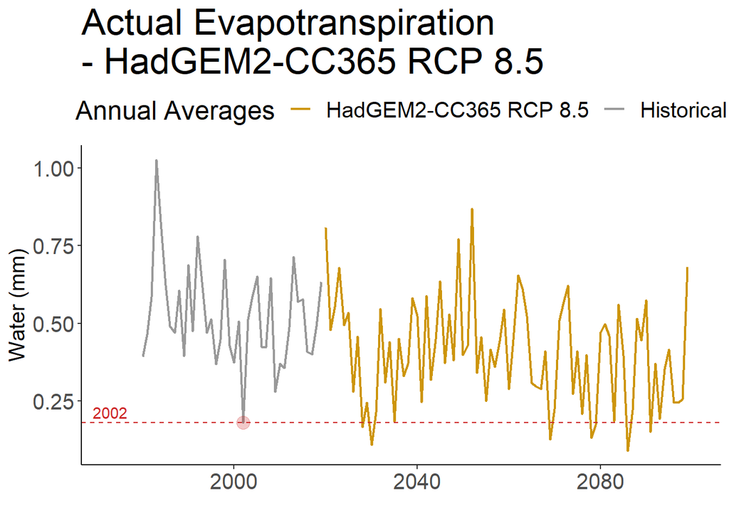

## Soil Water

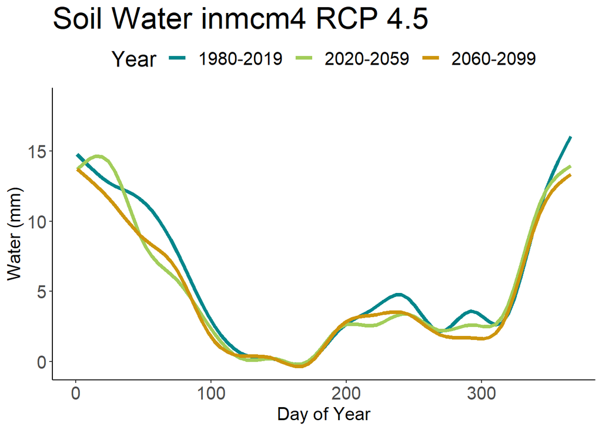

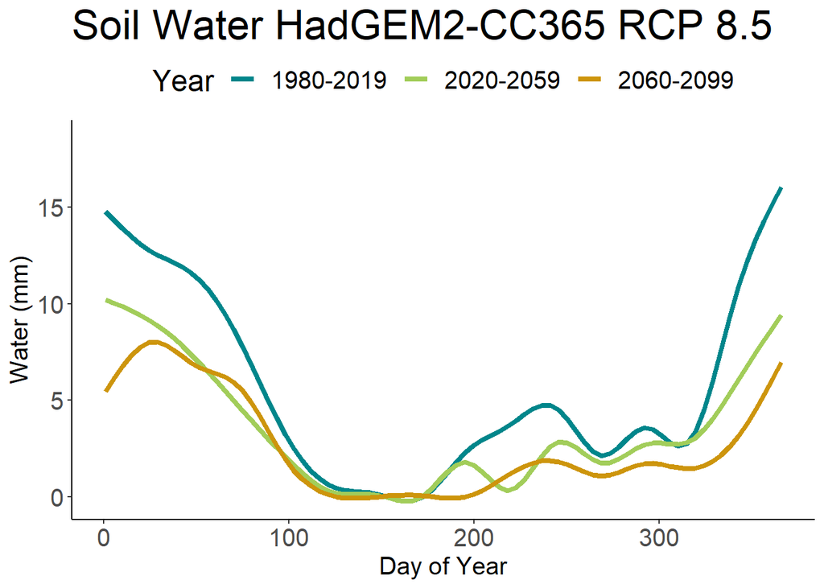

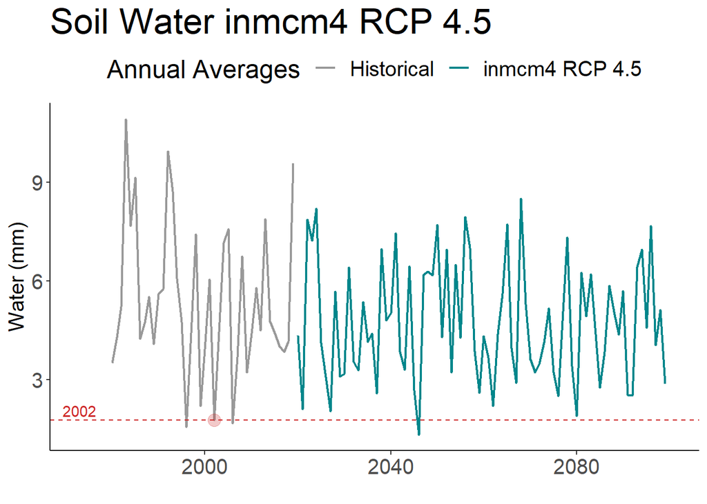

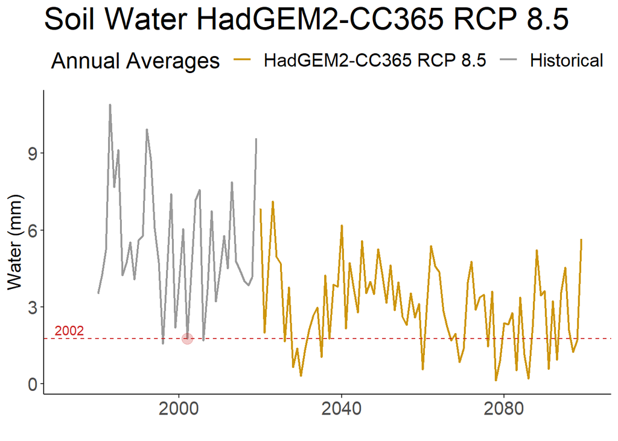

Decrease in soil water in the future under both climate futures. Under the HadGEM2-CC365 RCP 8.5 there is a large decrease in soil moisture in the late summer as a result of that decreased monsoon rain.

## Runoff

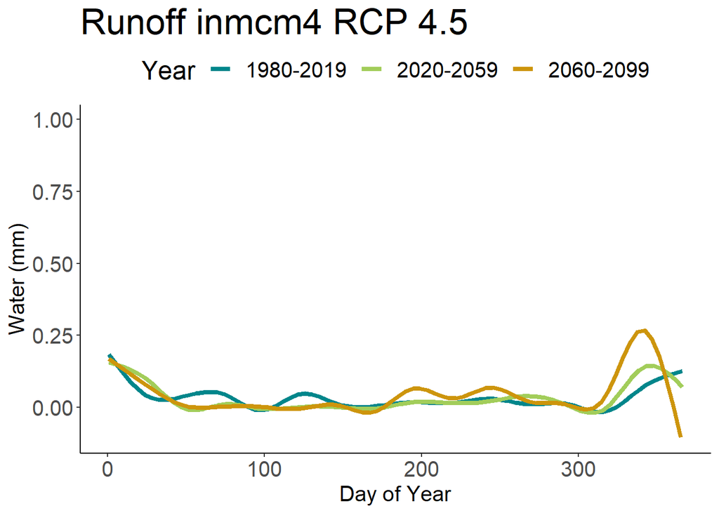

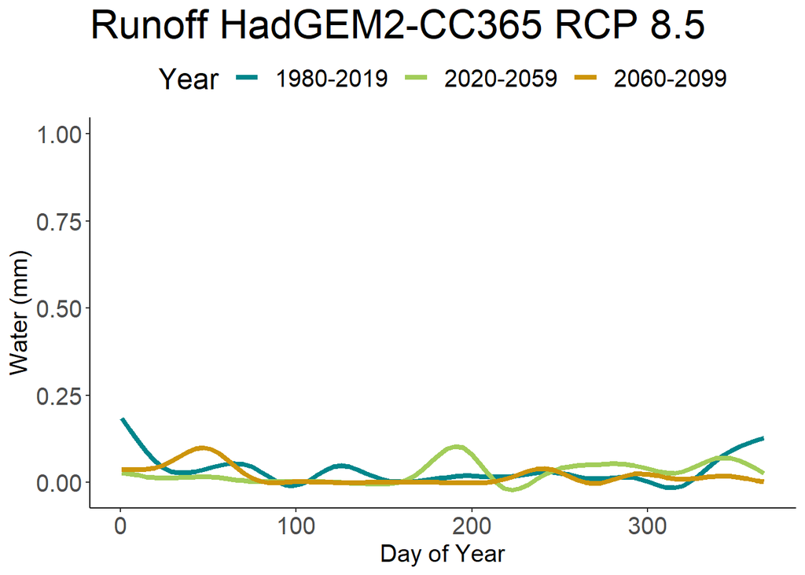

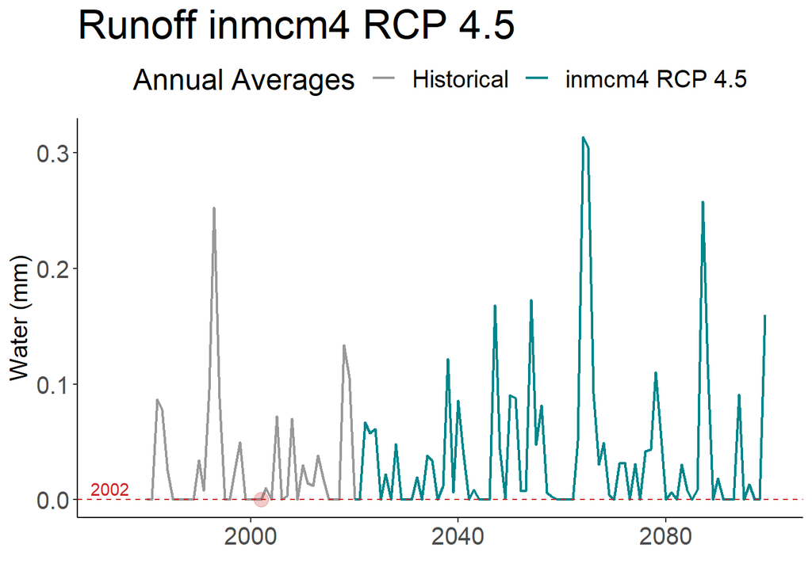

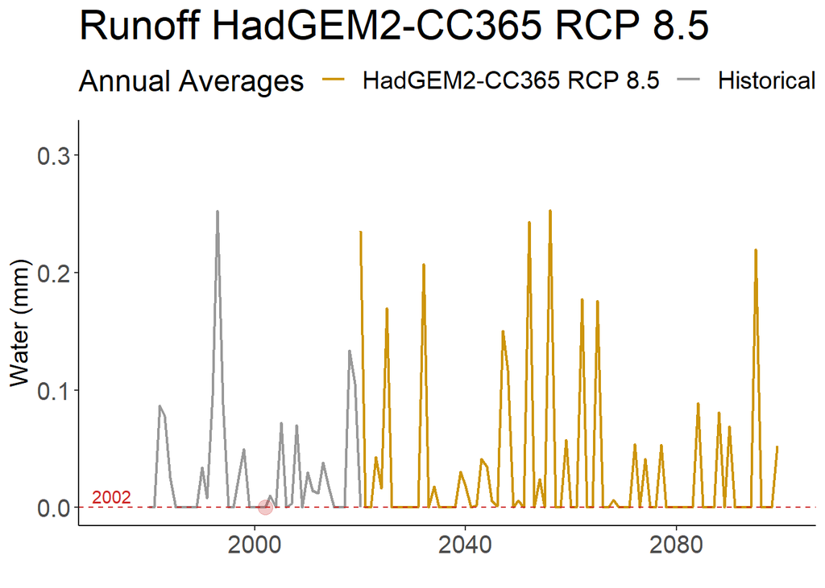

Although we have not investigated this thoroughly, we believe that the runoff is increasing in later decades as a result of possibly larger rain events in the future. In really wet years, you likely have more days in the year where there is runoff generation. There is simultaneously declining average annual precipitation *and* increased runoff due to precipitation occurring in larger events, resulting increased runoff wen it does rain.

To further explore this, we would want to look into the graphs on a daily time step, which we could do at a later date. Runoff generation in this model is the combination of overland flow plus deep infiltration below the rooting zone.

## Deficit

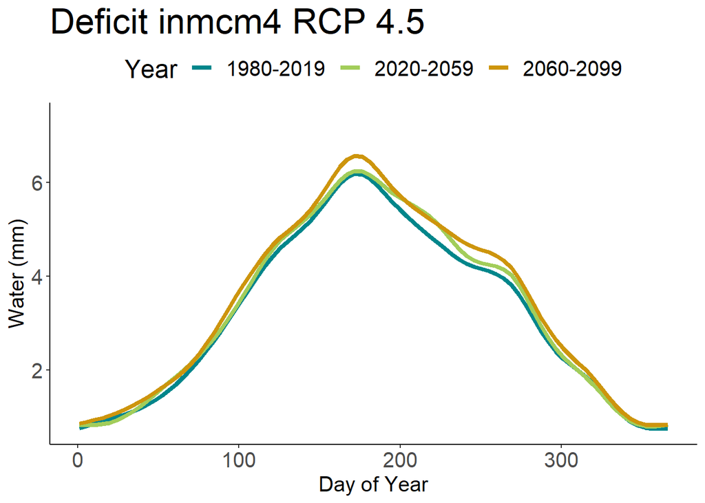

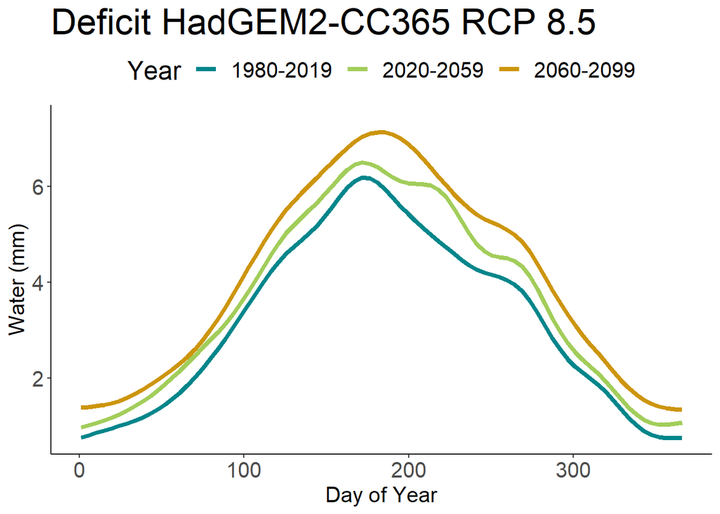

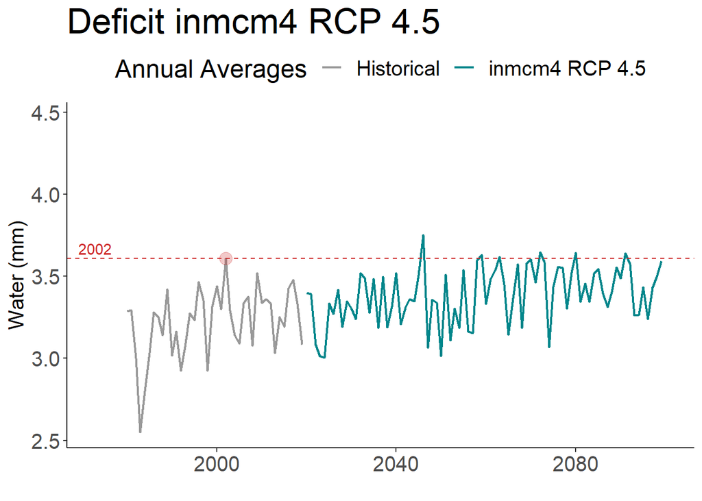

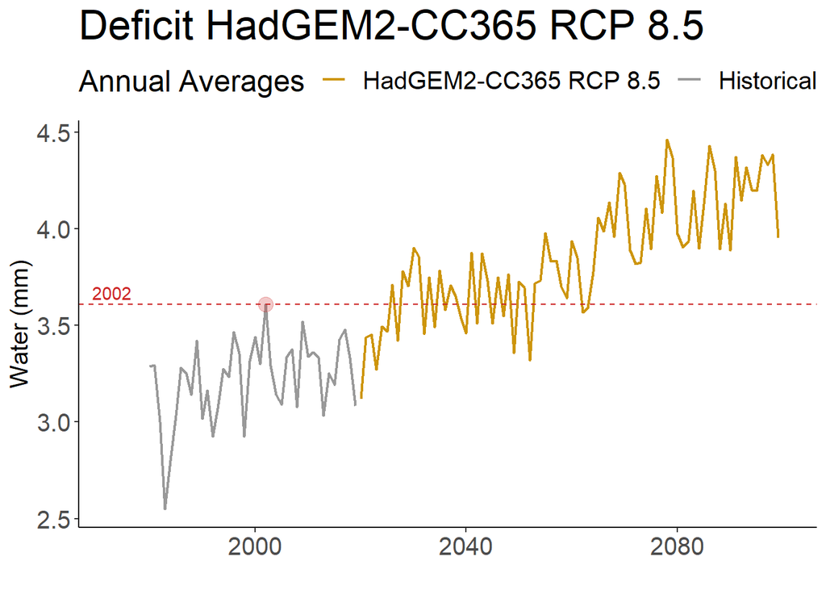

## Potential Evapotranspiration

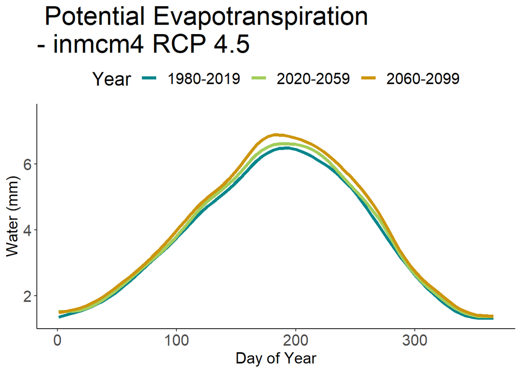

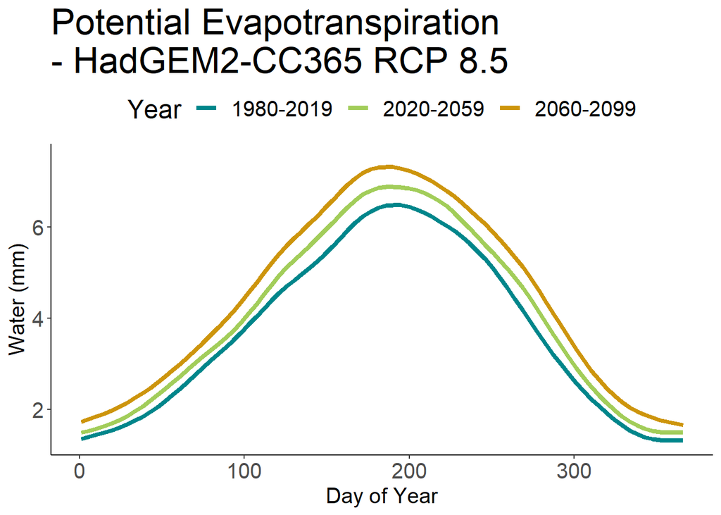

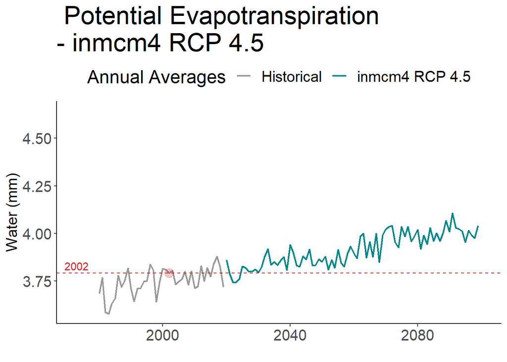

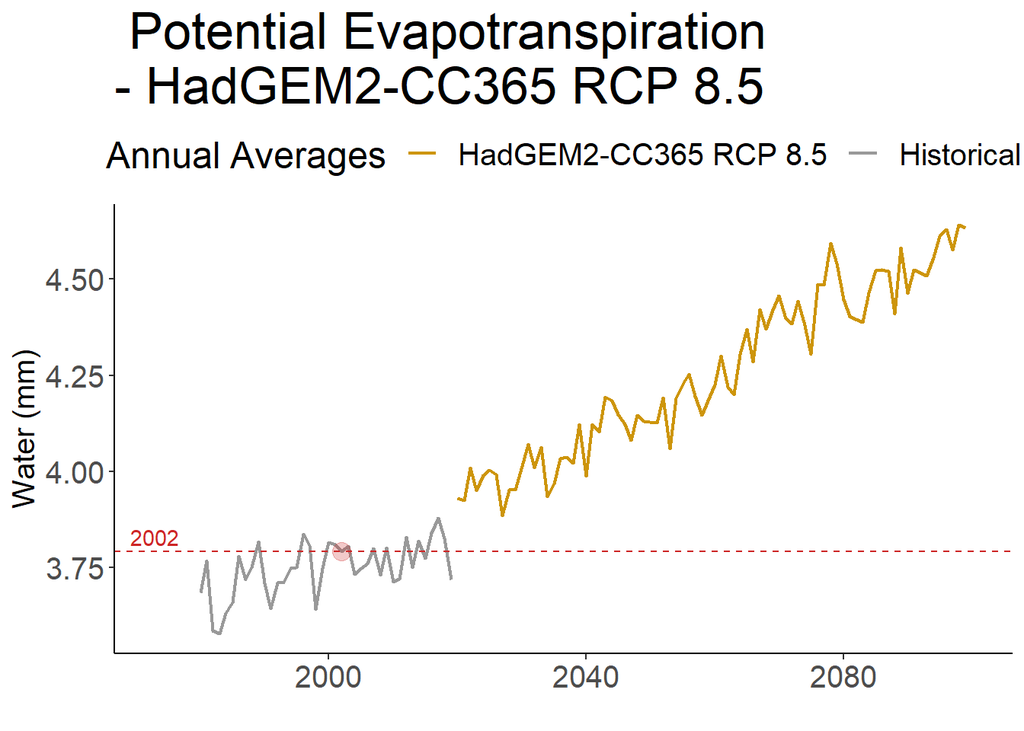

## Annual Average over time

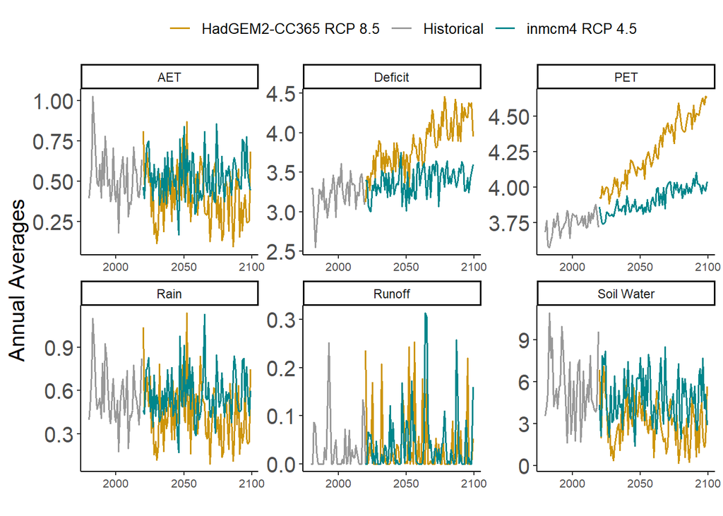

Annual averages over time. The gray line represents historical data modeled from gridmet climate data, the turquoise line represents climate model inmcm4 RCP 4.5 and the yellow line represents climate model HadGEM2-CC365 RCP 8.5